# Changing funnel plot options

## Setup

```r
library(FunnelPlotR)
```

This brief vignette shows how to go about changing some of the parameters available in the `FunnelPlotR` package. Firstly, lets set up some data, the same as the README and other vignette:

```r
library(COUNT)
```

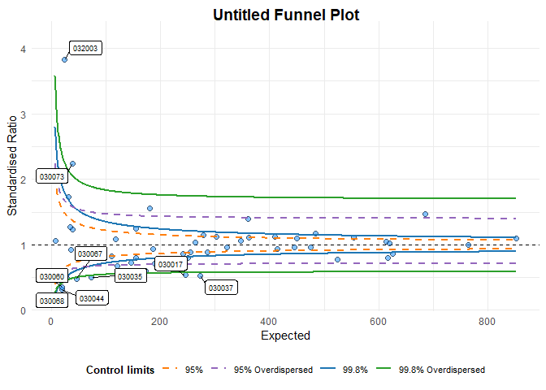

```
#> A funnel plot object with 54 points of which 9 are outliers.
#> Plot is adjusted for overdispersion.
```

```r
data(medpar)
medpar$provnum <- factor(medpar$provnum)
medpar$los <- as.numeric(medpar$los)

# Logistic model to predict LOS, LOS is quite overdispersed
mod <- glm(los ~ hmo + died + age80 + factor(type)
           , family = "poisson"
           , data = medpar)

#Get predicted value for ratio
medpar$prds <- predict(mod, newdata = medpar, type = "response")

# Draw plot, returning just the plot object
funnel_plot(medpar, denominator = prds, numerator = los
            , group = provnum
            , limit = 99
            , label = "outlier"
            , draw_unadjusted = TRUE)
```

## Highlighting a data point

You can pick out data point(s) using the `highlight` option. Here we we use the example above to highlight the hospital labels ‘030002’ in the data set.

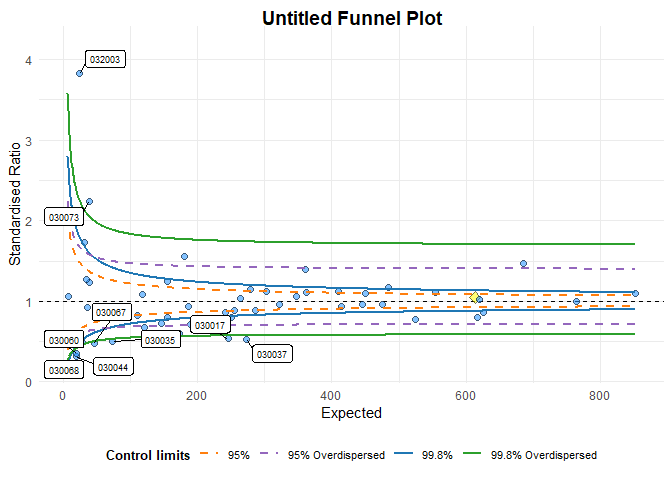

```
#> A funnel plot object with 54 points of which 9 are outliers.
#> Plot is adjusted for overdispersion.
```

```r
# Draw plot, returning just the plot object
funnel_plot(medpar, denominator = prds, numerator = los
            , group = provnum, limit = 99, label = "outlier"
            , draw_unadjusted = TRUE, highlight = "030002")
```

## Themes

You can alter themes in the `FunnelPlotR` packages by using the theme argument. There are a couple of options included with the package `funnel_clean` (the default) and `funnel_grey`, but you can write your own theme using any valid `ggplot2` theme and pass it to the plot.

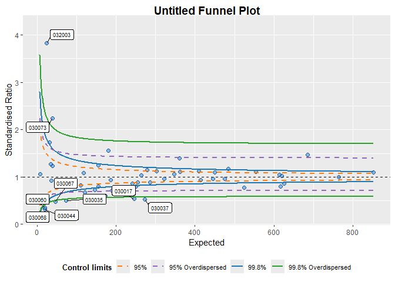

```
#> A funnel plot object with 54 points of which 9 are outliers.
#> Plot is adjusted for overdispersion.
```

```r
funnel_plot(medpar, denominator = prds, numerator = los
            , group = provnum, limit = 99, label = "outlier"
            , draw_unadjusted = TRUE, theme = funnel_grey())
```

If you are not familiar with themes, you can create a theme with the `theme` function from `ggplot2`. I will create a new theme, including the `funnel_grey` theme, but with some different (exaggerated) elements.

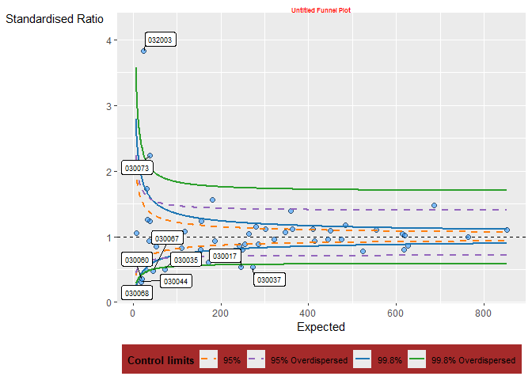

```
#> A funnel plot object with 54 points of which 9 are outliers.
#> Plot is adjusted for overdispersion.
```

```r
library(ggplot2)

new_funnel_theme <-
  funnel_grey() +
  # Change plot title
  theme(plot.title =  element_text(face = "bold", colour = "red", size = 6),
        # Alter legend background colour
        legend.background = element_rect(fill = "brown"),
        #Rotate y axis label
        axis.title.y = element_text(angle = 0))


funnel_plot(medpar, denominator = prds, numerator = los
            , group = provnum, limit = 99, label = "outlier"
            , draw_unadjusted = TRUE, theme = new_funnel_theme)
```